# Cyclistic bike-share analysis case study

Elvin Suleymanov

2024-10-09

## Introduction

Welcome to the Cyclistic bike-share analysis case study! This is one of the case studies in the Google Data Analytics Course. In this case study, I work for a fictional company Cyclistic. I have decided to use R for this analysis.

## Scenario

Cyclistic is a bike-share company. The marketing director believes the company’s future success depends on maximizing the number of annual memberships. I want to understand how casual riders and annual members use Cyclistic bikes differently. This is one of the questions in the **Ask** phase assigned to me.

## Data preparation

I am using the previous 12 months of Cyclistic’s historical trip data. There are in *.csv* file format. As a first step, I will combine all 12 months of data. In a code chunk below I set the path as a *(folder_path)* to the folder where I have stored *.csv* files.

```r
folder_path <- "D:/data_practice/case_study_cyclistic/01_raw_data_cyclistic"
```

I use *list.files()* to get a list of all *.csv* files in the folder

```r
csv_files <- list.files(path = folder_path, pattern = "*.csv", full.names = TRUE)
```

Then I use *lapply()* to read all *.csv* files into a list of data frames.

```r
list_of_dataframe <- lapply(csv_files, read.csv)
```

Finally I use *rbind()* to combine al 12 files.

```r
combined_dataframe <- do.call(rbind, list_of_dataframe)
summary(combined_dataframe)
```

```
##    ride_id          rideable_type       started_at          ended_at
##  Length:5699639     Length:5699639     Length:5699639     Length:5699639
##  Class :character   Class :character   Class :character   Class :character
##  Mode  :character   Mode  :character   Mode  :character   Mode  :character
##
##
##
##
##  start_station_name start_station_id   end_station_name   end_station_id
##  Length:5699639     Length:5699639     Length:5699639     Length:5699639
##  Class :character   Class :character   Class :character   Class :character
##  Mode  :character   Mode  :character   Mode  :character   Mode  :character
##
##
##
##
##    start_lat       start_lng         end_lat         end_lng
##  Min.   :41.64   Min.   :-87.94   Min.   :16.06   Min.   :-144.05
##  1st Qu.:41.88   1st Qu.:-87.66   1st Qu.:41.88   1st Qu.: -87.66
##  Median :41.90   Median :-87.64   Median :41.90   Median : -87.64
##  Mean   :41.90   Mean   :-87.65   Mean   :41.90   Mean   : -87.65
##  3rd Qu.:41.93   3rd Qu.:-87.63   3rd Qu.:41.93   3rd Qu.: -87.63
##  Max.   :42.07   Max.   :-87.52   Max.   :87.96   Max.   : -79.02
##                                   NA's   :7526    NA's   :7526
##  member_casual
##  Length:5699639
##  Class :character
##  Mode  :character
##
##
##
##
```

## Data cleaning

After combining the data and getting the summary we see that there are **5 699 639** rows and **13** variables. I want to ensure that there are no duplicate rows.

```r
cyclistic_data <- combined_dataframe %>% distinct()
```

There are no duplicates. Now I check for missing values in each column.

```r
colSums(is.na(cyclistic_data))
```

```
##            ride_id      rideable_type         started_at           ended_at
##                  0                  0                  0                  0
## start_station_name   start_station_id   end_station_name     end_station_id
##                  0                  0                  0                  0
##          start_lat          start_lng            end_lat            end_lng
##                  0                  0               7526               7526
##      member_casual
##                  0
```

There are **7526** missing values in the *end_lat* and *end_lng* columns. Since I’m not planning to use the starting and ending coordinates in my analysis, I decided to delete not only the rows with missing values but also the following variables: *start_lat*, *start_lng*, *end_lat*, *end_lng*.

```r
cyclistic_data <- cyclistic_data %>% select(-c(start_lat, start_lng, end_lat, end_lng))
```

Before checking for missing values I want to check for empty strings. We may have columns that didn’t appear as a missing value because of the empty strings. The code below will show us if we have empty strings and how many are in each column.

```r
empty_string_check <- sapply(cyclistic_data, function(x) sum (x == ""))
empty_string_check
```

```
##            ride_id      rideable_type         started_at           ended_at
##                  0                  0                  0                  0
## start_station_name   start_station_id   end_station_name     end_station_id
##             968697             968697            1006133            1006133
##      member_casual
##                  0
```

We have way too many empty strings in both *start_station_id* and *end_station_id* and if we filter we see there are **472 808** rows where both of these two variables are missing. For now, I will leave these values without making any changes.

```r
# Count rows where both 'start_station_id' and 'end_station_id' are empty strings
sum_empty_both <- cyclistic_data %>%
  filter(start_station_id == "" & end_station_id == "") %>%
  nrow()

# Display the result
sum_empty_both
```

```
## [1] 472808
```

## Data structure

Now we can inspect the structure of our data. With the *summary()* code below we can inspect our column names and variable types.

```r
summary(cyclistic_data)
```

```
##    ride_id          rideable_type       started_at          ended_at
##  Length:5699639     Length:5699639     Length:5699639     Length:5699639
##  Class :character   Class :character   Class :character   Class :character
##  Mode  :character   Mode  :character   Mode  :character   Mode  :character
##  start_station_name start_station_id   end_station_name   end_station_id
##  Length:5699639     Length:5699639     Length:5699639     Length:5699639
##  Class :character   Class :character   Class :character   Class :character
##  Mode  :character   Mode  :character   Mode  :character   Mode  :character
##  member_casual
##  Length:5699639
##  Class :character
##  Mode  :character
```

In the first column, we have a unique character type ID for each ride, we can check if they are all the same length. The length has to be 16.

```r
ride_id_length <- cyclistic_data %>% filter(nchar(ride_id) != 16)
head(ride_id_length)
```

```
## [1] ride_id            rideable_type      started_at         ended_at
## [5] start_station_name start_station_id   end_station_name   end_station_id
## [9] member_casual
## <0 rows> (or 0-length row.names)
```

If we check, we can see that there are only two types of values in the *rideable_type* and *member_casual* columns. But for easier manipulation, I want to change the variable types to the **factor**.

```r
#check the variables first
unique(cyclistic_data$rideable_type)
```

```
## [1] "classic_bike"  "electric_bike"
```

```r
unique(cyclistic_data$member_casual)
```

```
## [1] "member" "casual"
```

```r
#change the variable type
cyclistic_data <- cyclistic_data %>%
  janitor::clean_names() %>%
  mutate(
    rideable_type = as.factor(rideable_type),
    member_casual = as.factor(member_casual)
  )

str(cyclistic_data)
```

```
## 'data.frame':    5699639 obs. of  9 variables:
##  $ ride_id           : chr  "743252713F32516B" "BE90D33D2240C614" "D47BBDDE7C40DD61" "6684E760BF9EA9B5" ...
##  $ rideable_type     : Factor w/ 2 levels "classic_bike",..: 1 2 1 1 2 1 2 2 1 1 ...
##  $ started_at        : chr  "2024-04-22 19:08:21" "2024-04-11 06:19:24" "2024-04-20 11:13:13" "2024-04-04 18:39:20" ...
##  $ ended_at          : chr  "2024-04-22 19:12:56" "2024-04-11 06:22:21" "2024-04-20 11:29:31" "2024-04-04 18:43:06" ...
##  $ start_station_name: chr  "Aberdeen St & Jackson Blvd" "Aberdeen St & Jackson Blvd" "Sheridan Rd & Montrose Ave" "Aberdeen St & Jackson Blvd" ...
##  $ start_station_id  : chr  "13157" "13157" "TA1307000107" "13157" ...
##  $ end_station_name  : chr  "Desplaines St & Jackson Blvd" "Desplaines St & Jackson Blvd" "Ashland Ave & Belle Plaine Ave" "Desplaines St & Jackson Blvd" ...
##  $ end_station_id    : chr  "15539" "15539" "13249" "15539" ...
##  $ member_casual     : Factor w/ 2 levels "casual","member": 2 2 2 2 2 2 2 2 2 2 ...
```

Now I want to change **started_at** and **ended_at** columns to date-time format to do calculations. Since our data spans from September 2023 to August 2024, and the month column is based on the full month name, the default sorting will be alphabetical (January to December), which is not suitable for this specific time frame. To ensure the months are ordered correctly (starting from September 2023 and ending in August 2024), we can manually set the levels for the month column in the right order.

```r
month_levels <- c("September", "October", "November", "December",
                  "January", "February", "March", "April",
                  "May", "June", "July", "August")


cyclistic_data <- cyclistic_data %>% mutate(
  started_at = as.POSIXct(started_at, format = "%Y-%m-%d %H:%M:%S"),
  ended_at = as.POSIXct(ended_at, format = "%Y-%m-%d %H:%M:%S"),
  month = format(started_at, "%B"),
  month = factor(month, levels = month_levels)
)
```

Now I add columns that list the date, month, day, and year of each ride. This will allow us to aggregate ride data for each month, day, or year. Before completing these operations we could only aggregate at the ride level

```r
cyclistic_data <- cyclistic_data %>%
mutate(
    ride_date = as.Date(started_at),              # Extract full date
    ride_year = year(started_at),                 # Extract year
    ride_day = day(started_at),                   # Extract day of the month
    ride_weekday = wday(started_at, label = TRUE) # Extract day of the week
  )
```

Now I can add some aggregations to our data. First I do aggregations to see ride length and add **ride_length** column to the data. After sorting by **ride_length** we can see some of them appear as negative values or zero.

```r
cyclistic_data <- cyclistic_data %>% mutate(
  ride_length = difftime(ended_at, started_at, units = "sec")
)
# Sort by ride_length
cyclistic_data <- cyclistic_data %>%
  arrange(ride_length)
head(cyclistic_data)
```

```
##            ride_id rideable_type          started_at            ended_at
## 1 F584D47AE67FD388  classic_bike 2023-11-05 21:08:17 2023-10-25 07:31:46
## 2 AE046C379C20B7CA  classic_bike 2023-11-05 20:46:59 2023-10-25 07:31:46
## 3 A21D6507DA3C5AD4  classic_bike 2023-11-05 16:41:54 2023-10-25 07:31:46
## 4 DEC5EF8DE27398A0  classic_bike 2023-11-05 11:56:19 2023-10-25 07:31:46
## 5 7850F6E2343BF766  classic_bike 2023-11-01 16:38:10 2023-10-25 07:31:46
## 6 5A5DDAFFF234FB69  classic_bike 2023-11-01 14:07:31 2023-10-25 07:31:46
##                start_station_name start_station_id end_station_name
## 1    Sheffield Ave & Waveland Ave     TA1307000126
## 2    Sheridan Rd & Irving Park Rd            13063
## 3 Pine Grove Ave & Irving Park Rd     TA1308000022
## 4 Pine Grove Ave & Irving Park Rd     TA1308000022
## 5          Clark St & Drummond Pl     TA1307000142
## 6          Clark St & Drummond Pl     TA1307000142
##   end_station_id member_casual    month  ride_date ride_year ride_day
## 1                       casual November 2023-11-05      2023        5
## 2                       member November 2023-11-05      2023        5
## 3                       member November 2023-11-05      2023        5
## 4                       casual November 2023-11-05      2023        5
## 5                       casual November 2023-11-01      2023        1
## 6                       member November 2023-11-01      2023        1
##   ride_weekday  ride_length
## 1          Sun -999391 secs
## 2          Sun -998113 secs
## 3          Sun -983408 secs
## 4          Sun -966273 secs
## 5          Wed -637584 secs
## 6          Wed -628545 secs
```

I want to delete rows with negative values, also the rows that appear as zero, this is because employees took bikes out of circulation for quality Control reasons.

```r
cyclistic_data <- cyclistic_data %>%
  filter(ride_length > 0)

str(cyclistic_data)
```

```
## 'data.frame':    5698376 obs. of  15 variables:
##  $ ride_id           : chr  "F0B135907C453F55" "4C6DF0896F0EF5E4" "250166616F21D4C4" "ECC6DF9A0A4158D8" ...
##  $ rideable_type     : Factor w/ 2 levels "classic_bike",..: 1 2 2 2 1 2 2 2 2 1 ...
##  $ started_at        : POSIXct, format: "2024-04-12 20:31:19" "2024-04-15 08:38:45" ...
##  $ ended_at          : POSIXct, format: "2024-04-12 20:31:20" "2024-04-15 08:38:46" ...
##  $ start_station_name: chr  "Clark St & North Ave" "N Green St & W Lake St" "Southport Ave & Wrightwood Ave" "Leavitt St & Archer Ave" ...
##  $ start_station_id  : chr  "13128" "20246.0" "TA1307000113" "KA1503000068" ...
##  $ end_station_name  : chr  "Clark St & North Ave" "N Green St & W Lake St" "Southport Ave & Wrightwood Ave" "Leavitt St & Archer Ave" ...
##  $ end_station_id    : chr  "13128" "20246.0" "TA1307000113" "KA1503000068" ...
##  $ member_casual     : Factor w/ 2 levels "casual","member": 1 1 2 2 2 1 2 2 1 2 ...
##  $ month             : Factor w/ 12 levels "September","October",..: 8 8 8 8 8 8 8 8 8 8 ...
##  $ ride_date         : Date, format: "2024-04-12" "2024-04-15" ...
##  $ ride_year         : num  2024 2024 2024 2024 2024 ...
##  $ ride_day          : int  12 15 16 28 2 18 10 21 19 19 ...
##  $ ride_weekday      : Ord.factor w/ 7 levels "Sun"<"Mon"<"Tue"<..: 6 2 3 1 3 5 4 1 6 6 ...
##  $ ride_length       : 'difftime' num  1 1 1 1 ...
##   ..- attr(*, "units")= chr "secs"
```

```r
cyclistic_data <- cyclistic_data %>%
  janitor::clean_names() %>%
   mutate(ride_length = as.numeric(ride_length)
  )
```

After the last inspection, I decided to delete rows with empty strings at **start_station_id** and **end_station_id**. The **ride_length** is less than a minute in most of these rows.

```r
cyclistic_data <- cyclistic_data %>%
  filter(start_station_id != "",
         end_station_id != "")
```

We still have a lot of rows with a ride length of less than one minute, since we’re analyzing rider behavior, especially to compare members and casual riders, rides shorter than 1 minute might not provide meaningful insight. Very short rides might skew summary statistics like average ride length. Removing them could give a more realistic picture of typical rides, especially when comparing the habits of casual riders and members.

```r
cyclistic_data <- cyclistic_data %>%
  filter(ride_length >= 60)
```

The last thing I want to change in our data is to change ride_length from seconds to minutes and round the value.

```r
cyclistic_data <- cyclistic_data %>%
  mutate(ride_length = round(ride_length / 60, 1))
```

## Data Analysis

Now that the data is cleaned and tidy, we can start our analysis. My task is to give the difference of how the members and casual users use Cyclistic bikes differently.

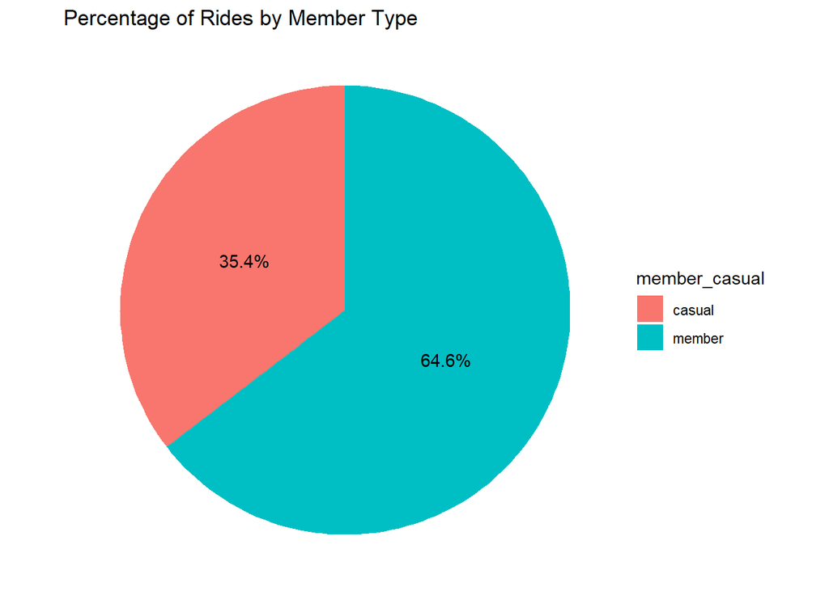

```r
member_type_difference <- cyclistic_data %>%
  group_by(member_casual) %>%
  summarise(count = n()) %>%
  mutate(percentage = round(100 * count / sum(count), 1))

#Let's use pie chart visualization for this.
ggplot(member_type_difference, aes(x = "", y = count, fill = member_casual)) +
  geom_bar(stat = "identity", width = 1) +
  coord_polar(theta = "y") +
  geom_text(aes(label = paste0(percentage, "%")), position = position_stack(vjust = 0.5)) +
  labs(title = "Percentage of Rides by Member Type") +
  theme_void()
```

Now let’s see the difference in the ride length between these two by calculating total ride time (in hours), average, median, maximum, and minimum values.

```r
ride_length_summary <- cyclistic_data %>%
  group_by(member_casual) %>%
  summarise(
    total_ride_length = sum(ride_length) / 60,
    average_ride_length = mean(ride_length),
    median_ride_length = median(ride_length),
    min_ride_length = min(ride_length),
    max_ride_length = max(ride_length)
  )

# Print the result to check
print(ride_length_summary)
```

```
## # A tibble: 2 × 6
##   member_casual total_ride_length average_ride_length median_ride_length
##   <fct>                     <dbl>               <dbl>              <dbl>
## 1 casual                  597748.                24.5               13.6
## 2 member                  564119.                12.6                8.9
## # ℹ 2 more variables: min_ride_length <dbl>, max_ride_length <dbl>
```

### Total Usage

**Total Ride Length:** Comparing the total ride length can show which group (members or casual riders) contributes more overall to the system’s usage. Casual riders contribute almost the same percentage to total ride length, they could represent a valuable target for marketing efforts to convert them into members.

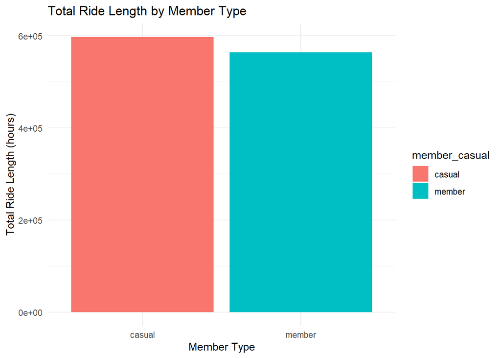

```r
ggplot(ride_length_summary, aes(x = member_casual, fill = member_casual)) +
  geom_bar(aes(y = total_ride_length), stat = "identity") +
  labs(title = "Total Ride Length by Member Type", x = "Member Type", y = "Total Ride Length (hours)") +
    theme_minimal()
```

### Ride Duration Patterns

**Average Ride Length Comparison:** We can compare the average ride length between members and casual riders. Casual riders taking longer rides on average than members. This could indicate that casual riders use the service for leisure, while members may use it for commuting or shorter trips.

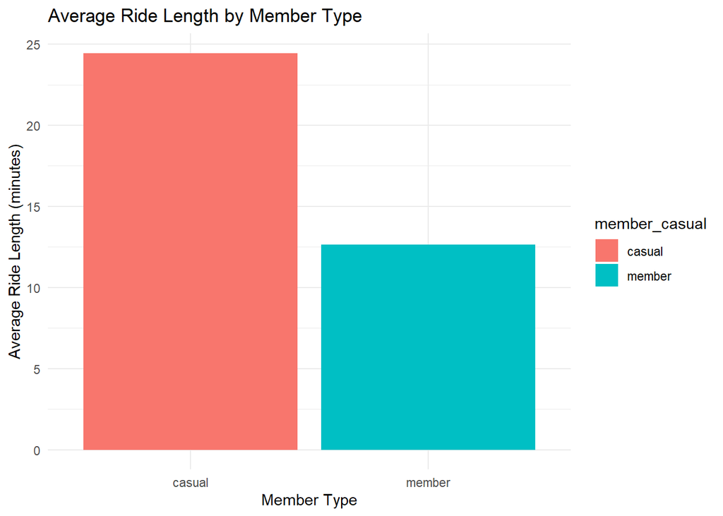

```r
ggplot(ride_length_summary, aes(x = member_casual, y = average_ride_length, fill = member_casual)) +
  geom_bar(stat = "identity") +
  labs(title = "Average Ride Length by Member Type", x = "Member Type", y = "Average Ride Length (minutes)") +
  theme_minimal()
```

### Day of the Week Patterns

Are there significant differences in ride lengths on weekdays versus weekends for each group? Below is the visualization that shows us the difference between weekdays for each group. Before visualization, I converted *ride_weekday* into a factor to control the order of days.

```r
day_levels <- c("Mon", "Tue", "Wed", "Thu", "Fri", "Sat", "Sun")
cyclistic_data$ride_weekday <- factor(cyclistic_data$ride_weekday, levels = day_levels)
```

Group by member type and day of the week, and calculate the number of rides, mean and total ride length.

```r
weekday_summary <- cyclistic_data %>%
  group_by(member_casual, ride_weekday) %>%
  summarise(
    ride_count = n(),
    average_ride_length = mean(ride_length, na.rm = TRUE),
    total_ride_length = sum(ride_length)
  )
```

**Create a Line Chart with ggplot2**

Casual riders prefer weekends while members use the service more on weekdays. This insight could suggest different user behaviors: casual riders might ride for leisure, while members use the service for work or daily activities.

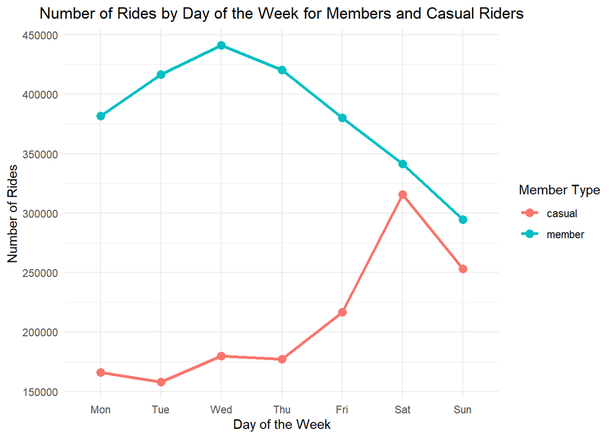

```r
ggplot(weekday_summary, aes(x = ride_weekday, y = ride_count, group = member_casual, color = member_casual)) +
  geom_line(size = 1.2) +      # Plot lines for each member type
  geom_point(size = 3) +       # Add points for emphasis
  labs(
    title = "Number of Rides by Day of the Week for Members and Casual Riders",
    x = "Day of the Week",
    y = "Number of Rides",
    color = "Member Type"
  ) +
  theme_minimal() +
  theme(
    plot.title = element_text(hjust = 0.5)
  )
```

Let’s create line chart showing **average ride length per day** for each member type.

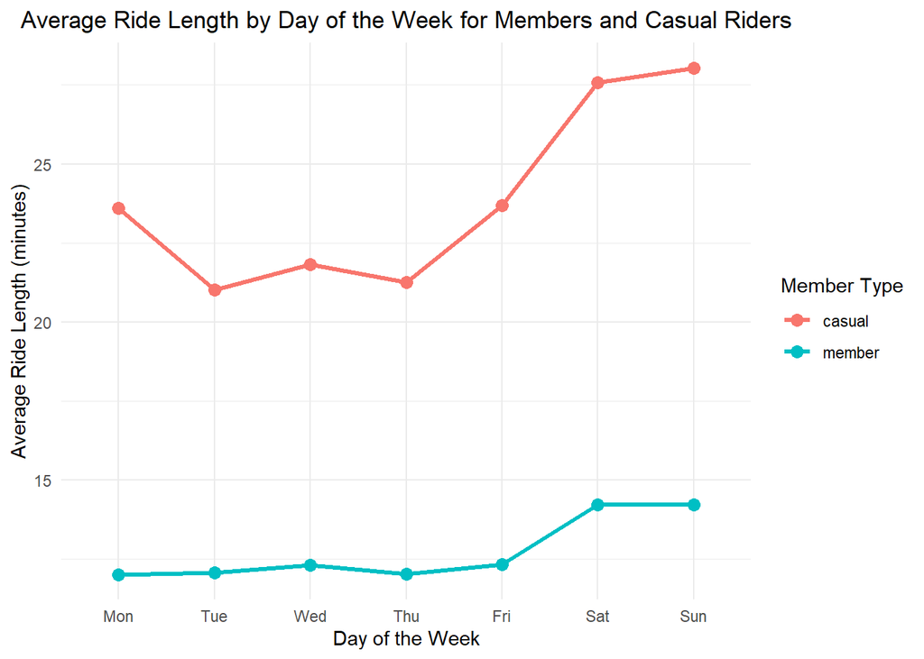

```r
ggplot(weekday_summary, aes(x = ride_weekday, y = average_ride_length, group = member_casual, color = member_casual)) +
  geom_line(size = 1.2) +        # Plot lines for each member type
  geom_point(size = 3) +         # Add points for emphasis
  labs(
    title = "Average Ride Length by Day of the Week for Members and Casual Riders",
    x = "Day of the Week",
    y = "Average Ride Length (minutes)",
    color = "Member Type"
  ) +
  theme_minimal() +
  theme(
    plot.title = element_text(hjust = 0.5)
  )
```

**Total ride length by day of the week**

We know that casual riders cycle longer if look at the average ride length. But if we look at the total ride length for each day of the week, we’ll see how the rides are different on weekdays and weekends. Casual riders start to ride more than members starting Friday while whole weekday members cycle longer.

[figure not shown]

```r
ggplot(weekday_summary, aes(x = ride_weekday, y = total_ride_length, fill = member_casual)) +
  geom_bar(stat = "identity", position = "dodge") +  # 'dodge' to place bars side by side
  labs(
    title = "Total Ride Length by Day of the Week for Members and Casual Riders",
    x = "Day of the Week",
    y = "Total Ride Length (hours)",
    fill = "Member Type"
  ) +
  theme_minimal() +
  theme(
    plot.title = element_text(hjust = 0.5)
  )
```

##Time of Year:

**Seasonal Patterns:**

Comparing ride data across months could reveal seasonal trends. Let’s find out if there any significant changes in ride behavior in winter vs. summer? Does one group contribute more during particular seasons?

First, let’s group by member type and months, and calculate the ride counts, average, and total ride length.

```r
seasonal_summary <- cyclistic_data %>%
  group_by(member_casual, month) %>%
  summarise(
    ride_count = n(),
    average_ride_length = mean(ride_length, na.rm = TRUE),
    total_ride_length = sum(ride_length) / 60
  )
```

### Ride Counts

Members exhibit more consistent ride behavior throughout the year, although they still experience a significant seasonal dip during the winter. Casual riders heavily favor the summer months, with a sharp drop in usage during the colder months. Both groups experience their **lowest** ride counts in **January**, and their highest in **July and August**, aligning with warmer weather and possibly vacation times.

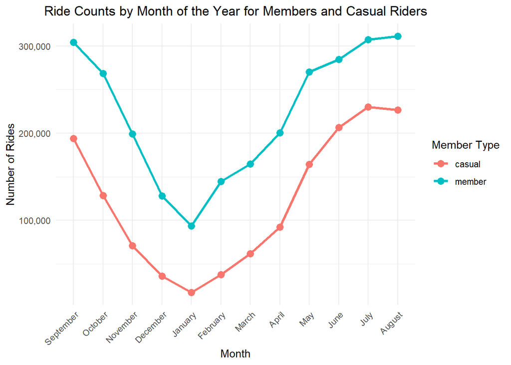

```r
ggplot(seasonal_summary, aes(x = month, y = ride_count, group = member_casual, color = member_casual)) +
  geom_line(size = 1.2) +        # Create lines for each member type
  geom_point(size = 3) +         # Add points for emphasis
  labs(
    title = "Ride Counts by Month of the Year for Members and Casual Riders",
    x = "Month",
    y = "Number of Rides",
    color = "Member Type"
  ) +
  scale_x_discrete(limits = month_levels) +  # Ensure the correct month order
  scale_y_continuous(labels = scales::comma) +  # Use comma format for large numbers
  theme_minimal() +
  theme(
    plot.title = element_text(hjust = 0.5),
    axis.text.x = element_text(angle = 45, hjust = 1)  # Rotate x-axis labels for better readability
  )
```

### Average ride length

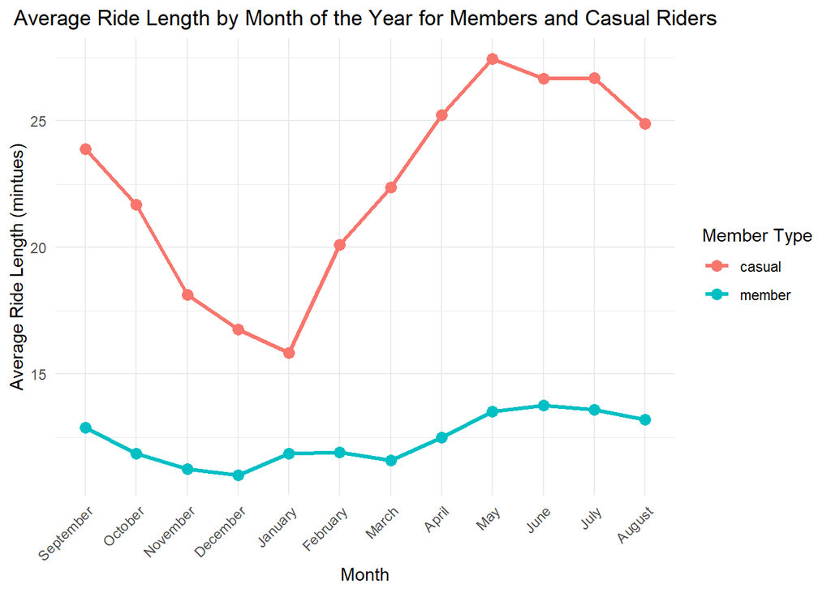

```r
ggplot(seasonal_summary, aes(x = month, y = average_ride_length, group = member_casual, color = member_casual)) +
  geom_line(size = 1.2) +        # Create lines for each member type
  geom_point(size = 3) +         # Add points for emphasis
  labs(
    title = "Average Ride Length by Month of the Year for Members and Casual Riders",
    x = "Month",
    y = "Average Ride Length (mintues)",
    color = "Member Type"
  ) +
  scale_x_discrete(limits = month_levels) +  # Ensure the correct month order
  scale_y_continuous(labels = scales::comma) +  # Use comma format for large numbers
  theme_minimal() +
  theme(
    plot.title = element_text(hjust = 0.5),
    axis.text.x = element_text(angle = 45, hjust = 1)  # Rotate x-axis labels for better readability
  )
```

### Total ride length

**Members:**

Members have a more consistent total ride length throughout the seasons, with their peak period being slightly longer, from June to September. During the winter and spring months (October to April), members consistently record a higher total ride length compared to casual riders, suggesting more year-round, committed usage. While casual riders surpass members in total ride length during the summer, members generally cycle more during the other months of the year.

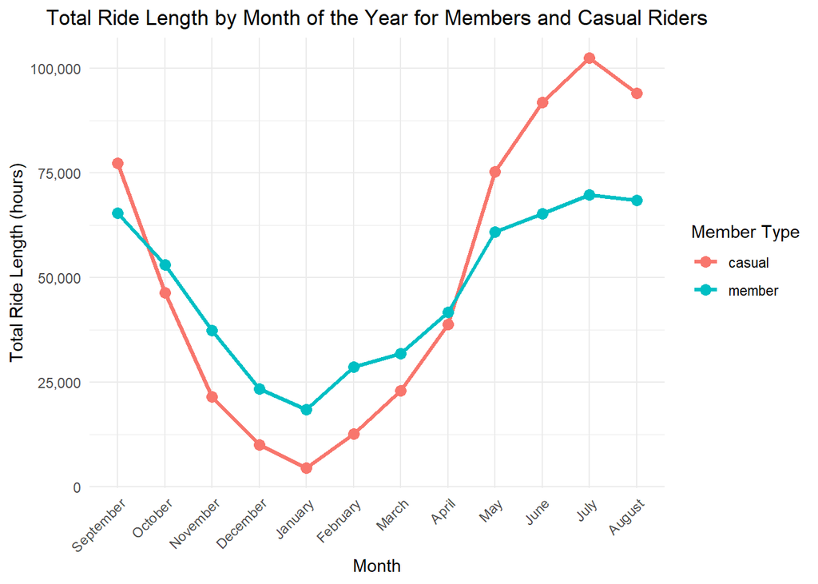

```r
ggplot(seasonal_summary, aes(x = month, y = total_ride_length, group = member_casual, color = member_casual)) +
  geom_line(size = 1.2) +        # Create lines for each member type
  geom_point(size = 3) +         # Add points for emphasis
  labs(
    title = "Total Ride Length by Month of the Year for Members and Casual Riders",
    x = "Month",
    y = "Total Ride Length (hours)",
    color = "Member Type"
  ) +
  scale_x_discrete(limits = month_levels) +  # Ensure the correct month order
  scale_y_continuous(labels = scales::comma) +  # Use comma format for large numbers
  theme_minimal() +
  theme(
    plot.title = element_text(hjust = 0.5),
    axis.text.x = element_text(angle = 45, hjust = 1)  # Rotate x-axis labels for better readability
  )
```

## Summary

### Casual Riders:

- Casual riders take approximately 1.8 times fewer rides than members, but their average ride length is about 2 times longer. Their total ride length throughout the year is similar to members.
- There is a significant gap in ride counts between weekdays and weekends, with casual riders taking fewer rides on weekdays. However, on weekends, they accumulate more total ride length than members.
- During weekdays, their total ride length is generally less than that of members, but Fridays show the closest balance between the two groups.
- Average ride length is higher than that of members but decreases from October, reaching a low in winter months, before increasing again in spring, peaking between May and July.
- Total ride length for casual riders is lower than members from October to April, but they experience a peak from June to August, where they exceed members, particularly in summer.

### Members:

- Members take more frequent but shorter rides compared to casual riders.
- Although their average ride length is about 2x shorter, their total ride length throughout the year is very close to casual riders.
- Members are more active on weekdays, with the number of rides decreasing slightly from Friday through the weekend.
- Their total ride length is consistent across weekdays, reflecting regular commuting or daily use.
- Members have a consistent average ride length throughout the year, with minor fluctuations.
- During the winter months (October to April), their total ride length is higher than casual riders, but during the peak months (June to September), casual riders surpass them in total ride length.

## Act

- If casual riders are taking frequent long rides, on weekends and in warmer months this might be an opportunity to offer them membership plans tailored to their needs, potentially converting them into members.
- Since casual riders are more active on weekends, offering weekend-only membership options could appeal to them. This could provide the convenience of unlimited rides on Saturdays and Sundays at a lower cost compared to a full membership.
- Casual riders tend to ride more during warmer months (spring and summer), so offering seasonal memberships for these months could be tempting. This would allow them to benefit from membership perks without committing to a full year.
- Casual riders have longer average ride lengths, so we could design membership tiers based on ride duration. For example, a plan that includes longer rides at a discounted rate might encourage them to become members.